# **Project Checkpoint 2**

### **Important Note**

The original, full dataset can be found here: https://cds.climate.copernicus.eu/datasets/reanalysis-era5-single-levels-monthly-means?tab=overview using the API call attached at the bottom of this notebook

This dataset is massive, thus we are using a significantly smaller subset to perform analysis on. The subset can be found on the GitHub page here: https://github.com/01Experi/CMSC320_SemesterProject inside the "Checkpoint_Submissions/Checkpoint_2" subdirectory with the title "weather.csv".

This notebook follows the subset data stored in the "weather.csv" dataset. At the bottom of this notebook includes the program created to take the original dataset and turn it into its current smaller form. That program takes a long time to run due to the sheer size of the original dataset and so it is highly recommended that it is not run. The program can also be found on the GitHub.

There is one other CSV file used in this notebook, "cities.csv." This is a self-created dataset used for the purpose of selecting weather data from certain cities. This file does not have to be examined as the entire dataset (only 30 entries) is printed below during Data Cleaning when imported, but also feel free to look it over as it is located in the same folder as "weather.csv".

## **Data Cleaning**

**Step 1.1:** Import necessary libraries

```python
import pandas as pd ## Data handeling
```

**Step 1.2:** Import dataset from CSV file

```python
weather_df = pd.read_csv("weather.csv")

weather_df.head()
```

|  | time | latitude | longitude | number | step | depthBelowLandLayer | valid_time | stl1 | surface | slt | sp | sd | u10 | v10 | t2m | d2m | sf | e | ro | tp |
| --- | --- | --- | --- | --- | --- | --- | --- | --- | --- | --- | --- | --- | --- | --- | --- | --- | --- | --- | --- | --- |
| 0 | 2021-01-01 06:00:00 | 35.75 | 139.75 | 0 | 0 days | 0.0 | NaN | NaN | 0.0 | NaN | NaN | NaN | NaN | NaN | NaN | NaN | 0.000000e+00 | -0.000041 | 0.000015 | 0.000065 |
| 1 | 2021-01-01 12:00:00 | 35.75 | 139.75 | 0 | 0 days | 0.0 | 2021-01-01 12:00:00 | 279.91925 | 0.0 | 3.0 | 101900.016 | 0.000084 | 0.187966 | -2.449815 | 277.37920 | 272.67170 | NaN | NaN | NaN | NaN |
| 2 | 2021-02-01 06:00:00 | 35.75 | 139.75 | 0 | 0 days | 0.0 | NaN | NaN | 0.0 | NaN | NaN | NaN | NaN | NaN | NaN | NaN | 2.980232e-08 | -0.000041 | 0.000011 | 0.000005 |
| 3 | 2021-02-01 12:00:00 | 35.75 | 139.75 | 0 | 0 days | 0.0 | 2021-02-01 12:00:00 | 281.76420 | 0.0 | 3.0 | 101633.664 | 0.000000 | 0.555573 | -0.719503 | 280.37323 | 273.26367 | NaN | NaN | NaN | NaN |
| 4 | 2021-03-01 06:00:00 | 35.75 | 139.75 | 0 | 0 days | 0.0 | NaN | NaN | 0.0 | NaN | NaN | NaN | NaN | NaN | NaN | NaN | 0.000000e+00 | -0.000030 | 0.000009 | 0.000077 |

**Step 1.3:** Keep important columns, discard the rest.

```python
weather_df = weather_df[['time', 'latitude', 'longitude', 'stl1', 'slt', 'sp', 'sd', 'u10', 'v10', 't2m', 'd2m', 'sf', 'e', 'ro', 'tp']]
```

**Step 1.4:** Display data types of **weather_df** columns.

```python
weather_df.dtypes
```

```
time             str
latitude     float64
longitude    float64
stl1         float64
slt          float64
sp           float64
sd           float64
u10          float64
v10          float64
t2m          float64
d2m          float64
sf           float64
e            float64
ro           float64
tp           float64
dtype: object
```

**Step 1.5:** Note that the 'time' column is stored as a string. We will convert it to a datetime object and only store the day, month, and year for convenience.

```python
weather_df['time'] = weather_df['time'].apply(
    lambda x : pd.to_datetime(x[0:10], format='%Y-%m-%d')
)

weather_df.head()
```

|  | time | latitude | longitude | stl1 | slt | sp | sd | u10 | v10 | t2m | d2m | sf | e | ro | tp |
| --- | --- | --- | --- | --- | --- | --- | --- | --- | --- | --- | --- | --- | --- | --- | --- |
| 0 | 2021-01-01 | 35.75 | 139.75 | NaN | NaN | NaN | NaN | NaN | NaN | NaN | NaN | 0.000000e+00 | -0.000041 | 0.000015 | 0.000065 |
| 1 | 2021-01-01 | 35.75 | 139.75 | 279.91925 | 3.0 | 101900.016 | 0.000084 | 0.187966 | -2.449815 | 277.37920 | 272.67170 | NaN | NaN | NaN | NaN |
| 2 | 2021-02-01 | 35.75 | 139.75 | NaN | NaN | NaN | NaN | NaN | NaN | NaN | NaN | 2.980232e-08 | -0.000041 | 0.000011 | 0.000005 |
| 3 | 2021-02-01 | 35.75 | 139.75 | 281.76420 | 3.0 | 101633.664 | 0.000000 | 0.555573 | -0.719503 | 280.37323 | 273.26367 | NaN | NaN | NaN | NaN |
| 4 | 2021-03-01 | 35.75 | 139.75 | NaN | NaN | NaN | NaN | NaN | NaN | NaN | NaN | 0.000000e+00 | -0.000030 | 0.000009 | 0.000077 |

**Step 1.6:** Due to the way the data was recorded, each location and time has two entires. One for ground data, and the other for air (more specifically: percipitation related data). For each entry, we will combine it with its pair to remove missing data.

```python
weather_df = weather_df.groupby(['time', 'latitude', 'longitude']).max().reset_index()

weather_df.head()
```

|  | time | latitude | longitude | stl1 | slt | sp | sd | u10 | v10 | t2m | d2m | sf | e | ro | tp |
| --- | --- | --- | --- | --- | --- | --- | --- | --- | --- | --- | --- | --- | --- | --- | --- |
| 0 | 2021-01-01 | -90.00 | 0.00 | 232.94269 | 1.0 | 68938.016 | 10.000000 | 0.380349 | 0.006728 | 244.23468 | 240.34161 | 0.000002 | 3.189780e-07 | 0.000000e+00 | 0.000002 |
| 1 | 2021-01-01 | -77.75 | 166.75 | 267.34894 | 0.0 | 96918.016 | 4.021423 | -1.187522 | -0.171983 | 268.30695 | 263.42755 | 0.000030 | -1.464179e-05 | 0.000000e+00 | 0.000030 |
| 2 | 2021-01-01 | -37.75 | 145.00 | 292.26690 | 4.0 | 100400.016 | 0.000000 | 0.876931 | 2.148818 | 290.45734 | 286.12677 | 0.000000 | -3.708294e-05 | 1.072884e-06 | 0.000082 |
| 3 | 2021-01-01 | -34.50 | 301.50 | 298.18097 | 0.0 | 101219.016 | 0.000000 | -0.640159 | -0.776475 | 296.24054 | 289.96466 | 0.000000 | -2.151071e-04 | 1.192093e-07 | 0.000067 |
| 4 | 2021-01-01 | -34.00 | 18.50 | 295.90167 | 1.0 | 100912.016 | 0.000000 | 0.170388 | 5.962783 | 294.80304 | 288.18146 | 0.000000 | -6.900122e-05 | 0.000000e+00 | 0.000003 |

**Step 1.7:** Rename columns for clarity.

```python
weather_df.columns = ['date', 'latitude', 'longitude', 'soil_temperature_level_1', 'soil_type', 'surface_pressure', 'snow_depth',
    'u_wind_10m', 'v_wind_10m', 'temperature_2m', 'dewpoint_temperature_2m', 'snowfall', 'evaporation', 'runoff', 'total_percipitation']

weather_df.head()
```

|  | date | latitude | longitude | soil_temperature_level_1 | soil_type | surface_pressure | snow_depth | u_wind_10m | v_wind_10m | temperature_2m | dewpoint_temperature_2m | snowfall | evaporation | runoff | total_percipitation |
| --- | --- | --- | --- | --- | --- | --- | --- | --- | --- | --- | --- | --- | --- | --- | --- |
| 0 | 2021-01-01 | -90.00 | 0.00 | 232.94269 | 1.0 | 68938.016 | 10.000000 | 0.380349 | 0.006728 | 244.23468 | 240.34161 | 0.000002 | 3.189780e-07 | 0.000000e+00 | 0.000002 |
| 1 | 2021-01-01 | -77.75 | 166.75 | 267.34894 | 0.0 | 96918.016 | 4.021423 | -1.187522 | -0.171983 | 268.30695 | 263.42755 | 0.000030 | -1.464179e-05 | 0.000000e+00 | 0.000030 |
| 2 | 2021-01-01 | -37.75 | 145.00 | 292.26690 | 4.0 | 100400.016 | 0.000000 | 0.876931 | 2.148818 | 290.45734 | 286.12677 | 0.000000 | -3.708294e-05 | 1.072884e-06 | 0.000082 |
| 3 | 2021-01-01 | -34.50 | 301.50 | 298.18097 | 0.0 | 101219.016 | 0.000000 | -0.640159 | -0.776475 | 296.24054 | 289.96466 | 0.000000 | -2.151071e-04 | 1.192093e-07 | 0.000067 |
| 4 | 2021-01-01 | -34.00 | 18.50 | 295.90167 | 1.0 | 100912.016 | 0.000000 | 0.170388 | 5.962783 | 294.80304 | 288.18146 | 0.000000 | -6.900122e-05 | 0.000000e+00 | 0.000003 |

**Step 1.8:** In order to add location name data to the dataset, we will use *cities.csv* which maps latitude and longitude to a city/location. First we need to import it into a dataframe.

```python
city_df = pd.read_csv('cities.csv')

city_df
```

|  | location | continent | latitude | longitude |
| --- | --- | --- | --- | --- |
| 0 | Tokyo, Japan | Asia | 35.75 | 139.75 |
| 1 | Singapore, Singapore | Asia | 1.25 | 103.75 |
| 2 | Dubai, UAE | Asia | 25.25 | 55.25 |
| 3 | Beijing, China | Asia | 40.00 | 116.50 |
| 4 | Mumbai, India | Asia | 19.00 | 73.00 |
| 5 | Seoul, South Korea | Asia | 37.50 | 127.00 |
| 6 | Bangkok, Thailand | Asia | 13.75 | 100.50 |
| 7 | New York City, NY | North America | 40.75 | 286.00 |
| 8 | Los Angeles, CA | North America | 34.00 | 241.75 |
| 9 | Chicago, IL | North America | 42.00 | 272.25 |
| 10 | Mexico City, Mexico | North America | 19.50 | 260.75 |
| 11 | Miami, FL | North America | 25.75 | 279.75 |
| 12 | Vancouver, Canada | North America | 49.25 | 237.00 |
| 13 | Sao Paulo, Brazil | South America | -23.50 | 313.25 |
| 14 | Buenos Aires, Argentina | South America | -34.50 | 301.50 |
| 15 | Lima, Peru | South America | -12.00 | 283.00 |
| 16 | Rio de Janeiro, Brazil | South America | -23.00 | 316.75 |
| 17 | Bogota, Colombia | South America | 4.75 | 286.00 |
| 18 | Cairo, Egypt | Africa | 30.00 | 31.25 |
| 19 | Lagos, Nigeria | Africa | 6.50 | 3.50 |
| 20 | Nairobi, Kenya | Africa | -1.25 | 36.75 |
| 21 | Cape Town, South Africa | Africa | -34.00 | 18.50 |
| 22 | London, United Kingdom | Europe | 51.50 | 0.00 |
| 23 | Paris, France | Europe | 48.75 | 2.25 |
| 24 | Moscow, Russia | Europe | 55.75 | 37.50 |
| 25 | Sydney, Australia | Oceania | -33.75 | 151.25 |
| 26 | Melbourne, Australia | Oceania | -37.75 | 145.00 |
| 27 | Perth, Australia | Oceania | -32.00 | 115.75 |
| 28 | McMurdo Station, Antarctica | Antarctica | -77.75 | 166.75 |
| 29 | Amundsen-Scott, Antarctica | Antarctica | -90.00 | 0.00 |

**Step 1.9:** Use **pandas** merge() function to combine the two dataframes on latitude and longitude.

```python
full_df = weather_df.merge(city_df, how='left', on=['longitude', 'latitude'])

full_df.head()
```

|  | date | latitude | longitude | soil_temperature_level_1 | soil_type | surface_pressure | snow_depth | u_wind_10m | v_wind_10m | temperature_2m | dewpoint_temperature_2m | snowfall | evaporation | runoff | total_percipitation | location | continent |
| --- | --- | --- | --- | --- | --- | --- | --- | --- | --- | --- | --- | --- | --- | --- | --- | --- | --- |
| 0 | 2021-01-01 | -90.00 | 0.00 | 232.94269 | 1.0 | 68938.016 | 10.000000 | 0.380349 | 0.006728 | 244.23468 | 240.34161 | 0.000002 | 3.189780e-07 | 0.000000e+00 | 0.000002 | Amundsen-Scott, Antarctica | Antarctica |
| 1 | 2021-01-01 | -77.75 | 166.75 | 267.34894 | 0.0 | 96918.016 | 4.021423 | -1.187522 | -0.171983 | 268.30695 | 263.42755 | 0.000030 | -1.464179e-05 | 0.000000e+00 | 0.000030 | McMurdo Station, Antarctica | Antarctica |
| 2 | 2021-01-01 | -37.75 | 145.00 | 292.26690 | 4.0 | 100400.016 | 0.000000 | 0.876931 | 2.148818 | 290.45734 | 286.12677 | 0.000000 | -3.708294e-05 | 1.072884e-06 | 0.000082 | Melbourne, Australia | Oceania |
| 3 | 2021-01-01 | -34.50 | 301.50 | 298.18097 | 0.0 | 101219.016 | 0.000000 | -0.640159 | -0.776475 | 296.24054 | 289.96466 | 0.000000 | -2.151071e-04 | 1.192093e-07 | 0.000067 | Buenos Aires, Argentina | South America |
| 4 | 2021-01-01 | -34.00 | 18.50 | 295.90167 | 1.0 | 100912.016 | 0.000000 | 0.170388 | 5.962783 | 294.80304 | 288.18146 | 0.000000 | -6.900122e-05 | 0.000000e+00 | 0.000003 | Cape Town, South Africa | Africa |

**Step 1.10:** From looking at the dtypes earlier, we note that soil_type is stored as a float64 despite containing int (whole number) data. soil_type is categorical data stored through ordinal encoding. While we are at it, we will reorder the column order to make things more ordered and grouped together visually.

```python
full_df['soil_type'] = full_df['soil_type'].astype('int64')

full_df = full_df[['location', 'continent', 'date', 'latitude', 'longitude', 'temperature_2m', 'surface_pressure', 'dewpoint_temperature_2m'
    , 'v_wind_10m', 'u_wind_10m', 'evaporation', 'runoff', 'total_percipitation', 'snowfall', 'snow_depth', 'soil_temperature_level_1', 'soil_type']]

full_df.head()
```

|  | location | continent | date | latitude | longitude | temperature_2m | surface_pressure | dewpoint_temperature_2m | v_wind_10m | u_wind_10m | evaporation | runoff | total_percipitation | snowfall | snow_depth | soil_temperature_level_1 | soil_type |
| --- | --- | --- | --- | --- | --- | --- | --- | --- | --- | --- | --- | --- | --- | --- | --- | --- | --- |
| 0 | Amundsen-Scott, Antarctica | Antarctica | 2021-01-01 | -90.00 | 0.00 | 244.23468 | 68938.016 | 240.34161 | 0.006728 | 0.380349 | 3.189780e-07 | 0.000000e+00 | 0.000002 | 0.000002 | 10.000000 | 232.94269 | 1 |
| 1 | McMurdo Station, Antarctica | Antarctica | 2021-01-01 | -77.75 | 166.75 | 268.30695 | 96918.016 | 263.42755 | -0.171983 | -1.187522 | -1.464179e-05 | 0.000000e+00 | 0.000030 | 0.000030 | 4.021423 | 267.34894 | 0 |
| 2 | Melbourne, Australia | Oceania | 2021-01-01 | -37.75 | 145.00 | 290.45734 | 100400.016 | 286.12677 | 2.148818 | 0.876931 | -3.708294e-05 | 1.072884e-06 | 0.000082 | 0.000000 | 0.000000 | 292.26690 | 4 |
| 3 | Buenos Aires, Argentina | South America | 2021-01-01 | -34.50 | 301.50 | 296.24054 | 101219.016 | 289.96466 | -0.776475 | -0.640159 | -2.151071e-04 | 1.192093e-07 | 0.000067 | 0.000000 | 0.000000 | 298.18097 | 0 |
| 4 | Cape Town, South Africa | Africa | 2021-01-01 | -34.00 | 18.50 | 294.80304 | 100912.016 | 288.18146 | 5.962783 | 0.170388 | -6.900122e-05 | 0.000000e+00 | 0.000003 | 0.000000 | 0.000000 | 295.90167 | 1 |

**Step 1.11:** Before saving this dataframe into a file, we will first check that everything looks alright.

```python
full_df.info()
```

```
<class 'pandas.DataFrame'>
RangeIndex: 1800 entries, 0 to 1799
Data columns (total 17 columns):
 #   Column                    Non-Null Count  Dtype
---  ------                    --------------  -----
 0   location                  1800 non-null   str
 1   continent                 1800 non-null   str
 2   date                      1800 non-null   datetime64[us]
 3   latitude                  1800 non-null   float64
 4   longitude                 1800 non-null   float64
 5   temperature_2m            1800 non-null   float64
 6   surface_pressure          1800 non-null   float64
 7   dewpoint_temperature_2m   1800 non-null   float64
 8   v_wind_10m                1800 non-null   float64
 9   u_wind_10m                1800 non-null   float64
 10  evaporation               1800 non-null   float64
 11  runoff                    1800 non-null   float64
 12  total_percipitation       1800 non-null   float64
 13  snowfall                  1800 non-null   float64
 14  snow_depth                1800 non-null   float64
 15  soil_temperature_level_1  1800 non-null   float64
 16  soil_type                 1800 non-null   int64
dtypes: datetime64[us](1), float64(13), int64(1), str(2)
memory usage: 239.2 KB
```

We notice that there are no null values, and that every column is stored as the desired dtype. Now it is time to perform data exploration on the cleaned dataset.

## **Data Exploration**

**Step 2.1:** Import additional necessary libraries

```python
from scipy.stats import f_oneway ## For ANOVA test
from scipy.stats import tukey_hsd ## Post-hoc test for ANOVA

import matplotlib.pyplot as plt ## Plotting
import seaborn as sns ## Plotting
```

**Step 2.2:** Perform first data exploration.

Intro: One way that we are going to explore the dataset is by looking at how the different variables correlate to each other. Measuring the relationship between the variables can show us which variables are linked. The correlation number ranges from -1 (perfect negative correlation) to +1 (perfect positive correlation).

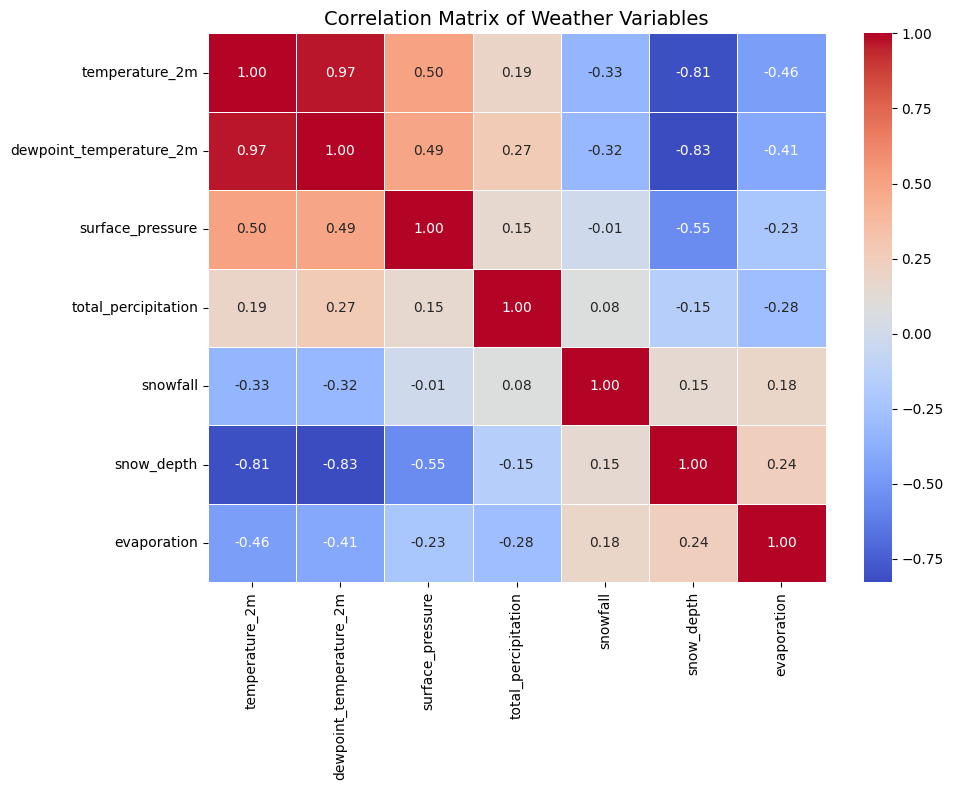

```python
df = full_df

corr_cols = [
    "temperature_2m",
    "dewpoint_temperature_2m",
    "surface_pressure",
    "total_percipitation",
    "snowfall",
    "snow_depth",
    "evaporation"
]

corr_matrix = df[corr_cols].corr()

plt.figure(figsize=(10, 8))
sns.heatmap(corr_matrix, annot=True, cmap="coolwarm", fmt=".2f", linewidths=0.5)
plt.title("Correlation Matrix of Weather Variables", fontsize=14)
plt.tight_layout()
plt.show()
```

Conclusion: It is clear that temperature and dewpoint are strongly correlated, .97, which makes sense since warm air holds more moisture, so they rise and fall together. Snow depth and temperature is strongly negatively correlated, -.81, pretty obvious that cold air leads to more snow. Snow depth and dewpoint are also strongly negative, -.83, because drier cold air means more snow sticks. Surface pressure and temperature are moderately positive, .5, since warmer air can create higher pressure systems. And precipitation is weakly correlated with pretty much everything, which is because rain depends on more complex factors, not just temperature.

**Step 2.3:** Perform second data exploration.

Intro: We can perform quantile analysis to determine how the spread of global temperature statistics is being affected by each continent.

```
--- Five-Number Summary for Temperature (K) ---
0.00    213.459440
0.25    283.468825
0.50    291.365230
0.75    298.432658
1.00    311.771500
Name: temperature_2m, dtype: float64

Global Mean: 288.29K
Global Median (50%): 291.37K
Skewness indicator (Mean - Median): -3.08

--- Grouped Temperature Statistics by Continent ---
                     mean         50%        std        min        max
continent
Africa         298.454338  298.651885   5.446771  287.24640  310.70563
Antarctica     241.780144  245.692750  16.364284  213.45944  269.04803
Asia           296.223089  300.549820  10.239304  269.03314  311.77150
Europe         286.253548  286.249695   8.321810  263.63990  300.32767
North America  285.538428  284.784350   8.040009  265.26776  301.52570
Oceania        289.908465  289.777985   4.371169  280.73035  299.07600
South America  291.196757  291.659500   5.516678  280.07648  302.48280
```

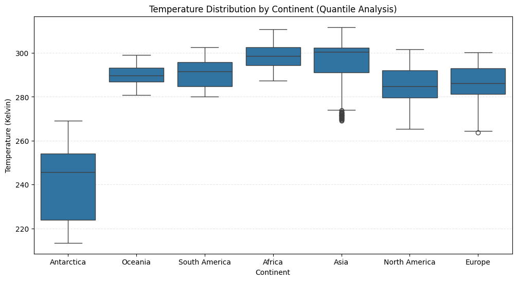

```python
df = full_df
temp_quantiles = df['temperature_2m'].quantile([0.0, 0.25, 0.5, 0.75, 1.0])
print("--- Five-Number Summary for Temperature (K) ---")
print(temp_quantiles)

mean = df['temperature_2m'].mean()
median = df['temperature_2m'].median()
print(f"\nGlobal Mean: {mean:.2f}K")
print(f"Global Median (50%): {median:.2f}K")
print(f"Skewness indicator (Mean - Median): {mean - median:.2f}")

grouped_stats = df.groupby('continent')['temperature_2m'].describe()
print("\n--- Grouped Temperature Statistics by Continent ---")
print(grouped_stats[['mean', '50%', 'std', 'min', 'max']])

plt.figure(figsize=(12, 6))
sns.boxplot(data=df, x='continent', y='temperature_2m')
plt.title('Temperature Distribution by Continent (Quantile Analysis)')
plt.ylabel('Temperature (Kelvin)')
plt.xlabel('Continent')
plt.grid(axis='y', linestyle='--', alpha=0.3)
plt.show()
```

Conclusion: The global temperature distribution is negatively skewed, as the mean is lower than the median. The box plot shows that this is due to how extreme the lows are in Antarctica compared to the rest of the world. Antarctica has a low of 213.46, which is roughly 50 degrees less than the low of the next closest continent, Europe.

**Step 2.4:** Perform third data exploration.

Intro: We perform a hypothesis test to determine whether the latitude band in which the cities reside have an effect on the total percipitation. We will do this by first running an ANOVA test then following it with a HSD post-hoc test to either support or reject the null hypothsis that total precipitation across latitude bands is the same.

```python
#Null Hypothesis: Total precipitation across latitude bands is the same.
#Alternative Hypothesis: Total precipitation across latitude bands is not the same.

hypo_df = full_df

hypo_df['latitude_bands'] = pd.cut(hypo_df['latitude'], bins=[-90, -30, 30, 90], labels=['Southern', 'Mid', 'Northern'], include_lowest=True)

hypo_df['total_precipitation_mm'] = hypo_df['total_percipitation'] * 1000
rainy_days_df = hypo_df[hypo_df['total_precipitation_mm'] > 0]
# rainy_days_df.groupby('latitude_bands')['total_precipitation_mm'].describe()

south = rainy_days_df[rainy_days_df['latitude_bands'] == 'Southern']['total_precipitation_mm']
mid = rainy_days_df[rainy_days_df['latitude_bands'] == 'Mid']['total_precipitation_mm']
north = rainy_days_df[rainy_days_df['latitude_bands'] == 'Northern']['total_precipitation_mm']


f_statistic, p_value = f_oneway(south, mid, north)

print(f"P-value: {p_value}")
```

```
P-value: 7.142553035675129e-11
```

```python
result = tukey_hsd(south, mid, north)
print(result)
```

```
Pairwise Group Comparisons (95.0% Confidence Interval)
Comparison  Statistic  p-value  Lower CI  Upper CI
 (0 - 1)     -0.062     0.000    -0.083    -0.040
 (0 - 2)     -0.044     0.000    -0.066    -0.022
 (1 - 0)      0.062     0.000     0.040     0.083
 (1 - 2)      0.018     0.076    -0.001     0.037
 (2 - 0)      0.044     0.000     0.022     0.066
 (2 - 1)     -0.018     0.076    -0.037     0.001
```

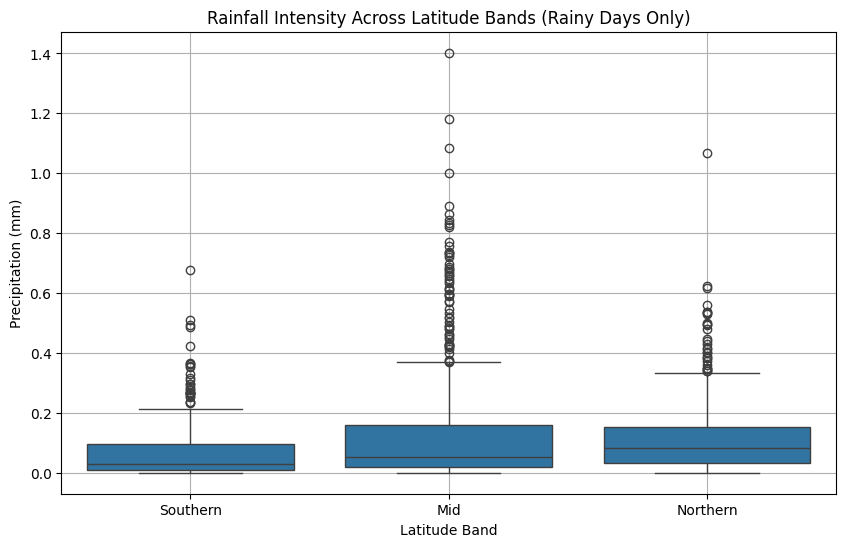

```python
plt.figure(figsize=(10,6))
sns.boxplot(data=rainy_days_df, x='latitude_bands', y='total_precipitation_mm')

plt.title('Rainfall Intensity Across Latitude Bands (Rainy Days Only)')
plt.xlabel('Latitude Band')
plt.ylabel('Precipitation (mm)')
plt.grid(True)

plt.show()
```

Conclusion: The ANOVA test indicates a significant difference in total precipitation across latitude bands (p-value < 0.05). The Tukey HSD post-hoc test reveals that the Southern band significantly differs from the Northern and Mid bands. However, there is statisically not much difference between the Northern and Mid Bands (p = 0.076). This is reflected in the boxplot as the Southern group has lower median rainfall and an overall smaller spread. Thus, we reject the null hypothesis at 5% significance level since the Southern latitude band significantly differs from the other two latitude bands.

## **Original Dataset Conversion** (To Show Work)

The following shows the program used to convert the original dataset into its smaller more manageable form. Do not run unless you have a good amount of RAM, the full dataset on hand, and are willing to wait a long time (like 30 minutes).

```python
# import pandas as pd
# import sqlite3
# import xarray as xr
# import cfgrib

# if __name__ == '__main__':

#     datasets = cfgrib.open_datasets('era5_subset.grib')
#     ds = xr.merge(datasets, compat='override', combine_attrs='drop')

#     # converting to DataFrame object risks memory overload due to limited RAM capacity for some computers
#     df = ds.to_dataframe().reset_index()

#     database_file = 'era5_database.sqlite'
#     main_table = 'main'

#     # connect to and create SQL database
#     conn = sqlite3.connect(database_file)

#     df.to_sql(main_table, conn, if_exists='replace', index=False, chunksize=10000)

#     # select subset from dataset based on selected cities/locations
#     city_df = pd.read_csv("cities.csv")
#     s_df = pd.read_sql("SELECT * FROM main LIMIT 0", conn) # get column format

#     # for each city get the associated datapoints
#     for _, row in city_df.iterrows(): # get all weather data for each location
#         query = f"""SELECT * FROM main WHERE latitude = {row['latitude']} AND longitude = {row['longitude']}"""
#         s_df = pd.concat([s_df, pd.read_sql(query, conn)], ignore_index=True)

#     # save subset as CSV file
#     s_df.to_csv("weather.csv", index=False)
#     conn.close()
```

## **API Call** (For Original Dataset)

Going to the original dataset linked at the top of this notebook, one can use the following API call to retrieve a subset of the full dataset (this notebook then uses a subset of that subset which is of a larger dataset)

```
dataset = "reanalysis-era5-single-levels-monthly-means"
request = {
"product_type": ["monthly_averaged_reanalysis_by_hour_of_day"],
"variable": [
    "10m_u_component_of_wind",
    "10m_v_component_of_wind",
    "2m_dewpoint_temperature",
    "2m_temperature",
    "surface_pressure",
    "total_precipitation",
    "evaporation",
    "runoff",
    "soil_temperature_level_1",
    "soil_type",
    "snowfall",
    "snow_depth"
],
"year": [
    "2021", "2022", "2023",
    "2024", "2025"
],
"month": [
    "01", "02", "03",
    "04", "05", "06",
    "07", "08", "09",
    "10", "11", "12"
],
"time": ["12:00"],
"data_format": "grib",
"download_format": "unarchived"
}
```